# Reconsidering Automatic Theory of Mind

Desmond C. Ong

October 13, 2014

This is an R Markdown document that accompanies the following manuscript:

Phillips, J., Ong, D. C., Surtees, A. D. R., Xin, Y., Williams, S., Saxe, R., & Frank, M. C. (accepted). A second look at automatic false belief representation: reconsidering Kovács, Téglás, and Endress (2010).

We have provided the raw data from all the experiments reported in the manuscript, as well as our analysis code. This document will walk through and allow you to reproduce the analyses that we have done. The text is from the paper.

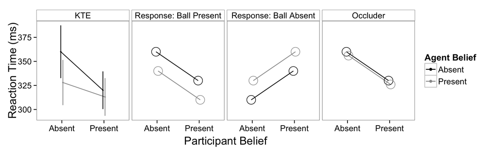

Figure 2: Left-most panel: data from KTE’s Experiment 1, estimated from KTE’s Fig. 2A. For purpose of comparison to other figures, error bars show 95% confidence intervals, rather than the standard error of the mean provided in the original. The next three panels show the pattern of reaction times that are predicted by Automatic ToM, for responding to “ball present” (second panel; identical to KTE’s paradigm), responding to “ball absent” (third panel; tested with our Studies 2–3), and responding to ball present in “occluder” trials, where there is an occluder between the agent and the ball at all times (fourth panel; tested with our Study 4).

## Study 1–4 Results

#### We replicate the critical statistical results of KTE (2010).

We replicated the main statistical comparisons reported by KTE. KTE’s t-tests (p. 1832) are reported along with the equivalent tests for Studies 1a–1c in Table 1. There are four main comparisons of interest. First, participants were faster to detect the ball when both the participant and the agent believed that the ball was present, compared to when neither did (P+A+ < P-A-; Cohen’s d = 0.284, 0.393, 0.654 respectively for Studies 1a,b,c; Cohen’s d = D / s where D is the difference between means, and s the standard deviation of the differences. p’s = 0.04, 0.001, 0.004).

```r
dValues # P+A+ < P-A- #
```

```
## [1] 0.2839 0.3930 0.6545
```

```r
pValues
```

```
## [1] 0.041798 0.001361 0.003920
```

Second, participants were also faster when they believed that the ball was present but the agent did not, as compared to when neither they nor the agent believed that it was present (P+A- < P-A-; d’s = 0.611, 0.555, 0.792; all p’s < 0.001). These first two comparisons confirm the expected result that the participant’s belief has an effect on the participant’s reaction time. Specifically, when the participant believes that the ball is present behind the occluder, the participant is faster to detect the ball, as compared to when the participant expects the ball to be absent (and is presumably surprised by the presence of the ball).

```r
dValues # P+A- < P-A- #
```

```
## [1] 0.6106 0.5545 0.7921
```

```r
pValues
```

```
## [1] 3.921e-05 1.216e-05 7.571e-04
```

Third, and most importantly, we also replicated the critical result that KTE interpreted as providing evidence for automatic ToM: Participants were faster to respond when the agent believed that the ball was present (and the participant did not), as compared to when neither believed it was present (P-A+ < P-A-; d’s = 0.594, 0.473, 0.422; p < 0.001, p < 0.001, p =0.05 respectively). Based on this comparison, KTE proposed that the agent’s belief facilitated participants’ detection of the ball.

```r
dValues # P-A+ < P-A- #
```

```
## [1] 0.5942 0.4726 0.4219
```

```r
pValues
```

```
## [1] 5.896e-05 1.481e-04 5.020e-02
```

Fourth, we replicated the null result that participants’ reaction times did not differ between the case when only the agent believed that the ball was present, and the case when only the participant had a belief that the ball was present (P-A+ ~ P+A-; d’s = 0.079, 0.062, 0.324; p’s = 0.57, 0.60, 0.13).. KTE suggest that both types of beliefs (participant beliefs and agent beliefs) individually facilitate reaction times to the same degree. All the statistical tests that were reported by KTE were replicated in all three studies; this robustness indicates that the effects that KTE reported are highly replicable across different sets of stimuli and different testing environments (online vs. in lab).

```r
# P-A+ ~ P+A- #
dValues
```

```
## [1] 0.07874 0.06242 0.32384
```

```r
pValues
```

```
## [1] 0.5653 0.5980 0.1263
```

Comparison Study t-statistic df p value Cohen’s d (P-A-) - (P+A+) KTE 3.47 23 0.002 0.708 1a 2.09 53 0.042 0.284 1b 3.33 71 0.001 0.393 1c 3.21 23 0.004 0.654 (P-A-) - (P+A-) KTE 3.43 23 0.002 0.700 1a 4.49 53 <.001 0.611 1b 4.71 71 <.001 0.555 1c 3.88 23 <.001 0.792 (P-A-) - (P-A+) KTE 2.42 23 0.02 0.494 1a 4.37 53 <.001 0.594 1b 4.01 71 <.001 0.473 1c 2.07 23 0.05 0.422 (P-A+) - (P+A-) KTE 0.99 23 0.33 n.s. 0.202 1a 0.58 53 0.57 n.s. 0.079 1b 0.53 71 0.60 n.s. 0.062 1c 1.59 23 0.13 n.s. 0.324

Table 1. Direct replication of results of Experiment 1 from KTE (2010) using Studies 1a–1c. The t, df, and p values from KTE were reported in the paper, while Cohen’s d for KTE’s studies were calculated from the t and df values.